# A Mapping of Denver Marijuana Businesses and Arrests

Author: David Martinez  
Institution: Regis University CLass: MSDS692 Data Science Practicum #1  
Professor: Dr. Michael Busch

### Introduction

On November 7th, 2000, voters in Colorado amended the state Constitution to allow the sale and use of Marijuana upon written consent by medical professional (Amendment 20, Colorado Constitution, 2000). Twelve years later, Colorado approved the sale and use of marijuana recreational use for adults over the age of twenty-one (Amendment 64, COlorado Constitution, 2012). Denver, the state capital and the largest population center in Colorado, has published data records since 2010 for medical marijuana and 2013 for recreational marijuana, including sales, government revenue, licensing information, and crime statistics.

This project will focus on identifying the types and locations of Marijuana businesses as well as the types and locations of arrests made.

The following datasets are used in this project:  
https://www.denvergov.org/opendata/dataset/city-and-county-of-denver-marijuana-active-business-licenses https://www.denvergov.org/opendata/dataset/city-and-county-of-denver-crime-marijuana

Other references:  
https://ballotpedia.org/Marijuana_on_the_ballot  
https://developers.google.com/maps/documentation/geocoding/usage-and-billing

citations: ggmap - D. Kahle and H. Wickham. ggmap: Spatial Visualization with ggplot2. The R Journal, 5(1), 144-161. URL http://journal.r-project.org/archive/2013-1/kahle-wickham.pdf

stringr - Hadley Wickham (2017). stringr: Simple, Consistent Wrappers for Common String Operations. R package version 1.2.0. https://CRAN.R-project.org/package=stringr

ggplot2 - H. Wickham. ggplot2: Elegant Graphics for Data Analysis. Springer-Verlag New York, 2009.

dplyr - Hadley Wickham, Romain Francois, Lionel Henry and Kirill Müller (2017). dplyr: A Grammar of Data Manipulation. R package version 0.7.4. https://CRAN.R-project.org/package=dplyr

RgoogleMaps - Markus Loecher and Karl Ropkins (2015). RgoogleMaps and loa: Unleashing R Graphics Power on Map Tiles. Journal of Statistical Software 63(4), 1-18. URL http://www.jstatsoft.org/v63/i04/.

### Retrieve Denver Marijuana Licenses

```r
library(stringr)  #string operations
library(ggplot2)  #graphics
library(ggmap)    #used for geocoding
library(dplyr)    #dataframe manipulation

#retrieve dataset from denvergov.org
denver_mj_licenses <- read.csv("https://www.denvergov.org/media/gis/DataCatalog/marijuana_active_business_licenses/csv/marijuana_active_business_licenses.csv", header=TRUE, stringsAsFactors = FALSE)

#create factor for license type
denver_mj_licenses$License.Type <- factor(denver_mj_licenses$License.Type)

#combine levels and rename for easier reading
denver_mj_licenses$License.Type <- plyr::revalue(denver_mj_licenses$License.Type, c("Med Marijuana Inf Prod Manuf" = "Infrastructure Production Manufacturing", "Retail Marijuana Inf Prod Mfg" = "Infrastructure Production Manufacturing", "Med Marijuana Test Facility" = "Marijuana Test Facility", "Retail Marijuana Test Facility" = "Marijuana Test Facility", "Med Marijuana Opt Prem Cultiv" = "Marijuana Grow Center", "Retail Marij Opt. Prem. Cultiv" = "Marijuana Grow Center"))

#create factor for zip code
denver_mj_licenses$Facility.Zip.Code <- factor(denver_mj_licenses$Facility.Zip.Code)

#current license status and expiration date don't appear to be very interesting so they can go
denver_mj_licenses <- denver_mj_licenses[-c(5:6)]

#convert street address information to one field for geocoding
num <- paste(word(denver_mj_licenses$Facility.Street.Number))
dir <- paste(word(denver_mj_licenses$Facility.Pre.Direction))
street <- paste(word(denver_mj_licenses$Facility.Street.Name))
type <- paste(word(denver_mj_licenses$Facility.Street.Type))
denver_mj_licenses$ADDRESS <- paste(num, dir, street, type, ", DENVER, CO", sep=" ")

#remove old address information (except zip code)
denver_mj_licenses <- denver_mj_licenses[-c(5:10)]

#geocode for lat/long - Data Science Toolkit (dsk) is used here instead of to retrieve the lat/long
for(i in 1:nrow(denver_mj_licenses)) {
  result <- geocode(denver_mj_licenses$ADDRESS[i], output="latlona", source="dsk")
  denver_mj_licenses$LONGITUDE[i] <- as.numeric(result[1])
  denver_mj_licenses$LATITUDE[i] <- as.numeric(result[2])
}

#save for posterity
#write.csv(denver_mj_licenses, "mj_licenses_geocoded.csv", row.names=FALSE)

summary(denver_mj_licenses)
```

```
##  Business.File.Number                                  License.Type
##  Length:1116          Marijuana Transporter                  :  6
##  Class :character     Infrastructure Production Manufacturing:186
##  Mode  :character     Marijuana Grow Center                  :562
##                       Marijuana Test Facility                : 10
##                       Medical Marijuana Center               :186
##                       Retail Marijuana Store                 :166
##
##  Entity.Name         Trade.Name        Facility.Zip.Code
##  Length:1116        Length:1116        80216  :277
##  Class :character   Class :character   80223  :242
##  Mode  :character   Mode  :character   80239  :168
##                                        80204  : 99
##                                        80207  : 41
##                                        (Other):267
##                                        NA's   : 22
##    ADDRESS            LONGITUDE         LATITUDE
##  Length:1116        Min.   :-105.1   Min.   :39.63
##  Class :character   1st Qu.:-105.0   1st Qu.:39.68
##  Mode  :character   Median :-105.0   Median :39.71
##                     Mean   :-105.0   Mean   :39.72
##                     3rd Qu.:-104.9   3rd Qu.:39.77
##                     Max.   :-104.8   Max.   :39.92
##
```

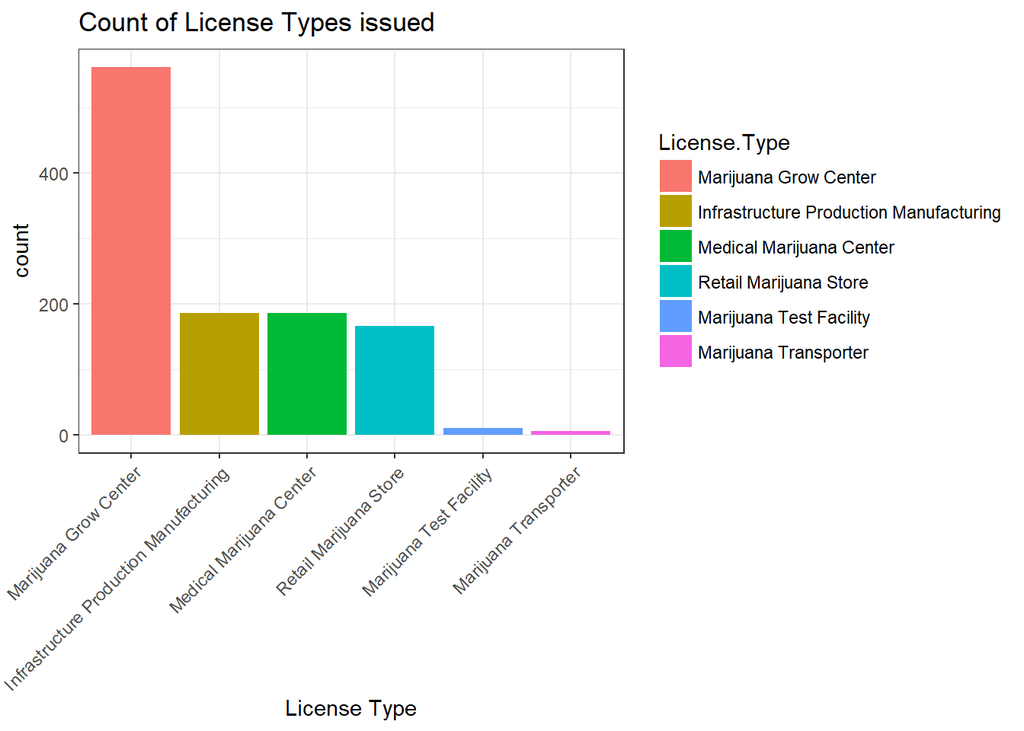

```r
#cleanup again - darn OCD
rm(i, num, dir, street, type, result)

#sort by License.Type
denver_mj_licenses <- within(denver_mj_licenses, License.Type <- factor(License.Type,
                                                                        levels=names(sort(table(License.Type), decreasing=TRUE))))

#generate plot to show graphically the number of license types issued
ggplot(denver_mj_licenses,aes(x=License.Type, fill=License.Type))+
  geom_bar()+
  labs(title="Count of License Types issued", x= "License Type")+
  theme_bw()+
  theme(axis.text.x = element_text(angle = 45, hjust = 1))
```

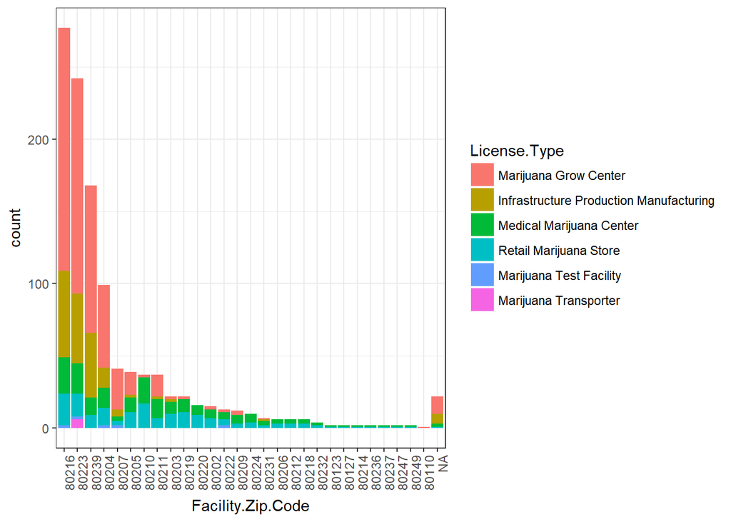

```r
#sort by Facility Zip Code
denver_mj_licenses <- within(denver_mj_licenses, Facility.Zip.Code <- factor(Facility.Zip.Code,
                                                                      levels=names(sort(table(Facility.Zip.Code), decreasing=TRUE))))
#generate plot to show where licenses are being issued
ggplot(denver_mj_licenses,aes(x=Facility.Zip.Code, fill=License.Type))+
  geom_bar()+
  theme_bw()+
  theme(axis.text.x = element_text(angle = 90, hjust = 1))
```

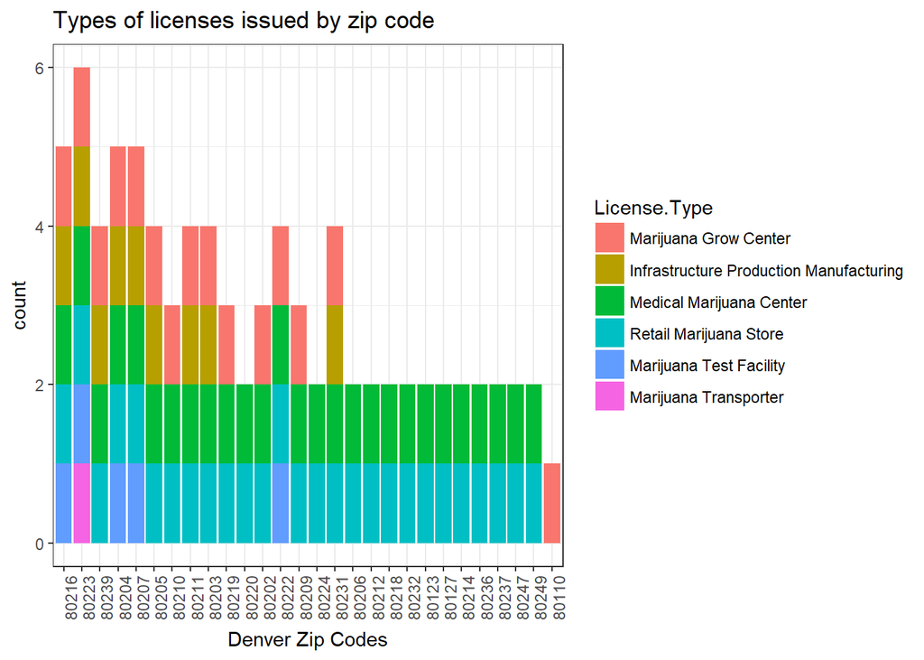

```r
#create a dataframe of the types of licenses issued to each zip code
zip_tab <- as.data.frame(table(denver_mj_licenses$Facility.Zip.Code, denver_mj_licenses$License.Type))

#rename for more descriptive tags
zip_tab <- rename(zip_tab, ZipCode = Var1, License.Type = Var2)

#filter out the 0 frequency occurences
zip_tab <- filter(zip_tab, zip_tab$Freq > 0)

#generate a plot to show the types of licenses issued to each zip code
ggplot(zip_tab,aes(x=ZipCode, fill=License.Type))+
  geom_bar()+
  labs(title="Types of licenses issued by zip code", x= "Denver Zip Codes")+
  theme_bw()+
  theme(axis.text.x = element_text(angle = 90, hjust = 1))
```

### Generating Maps